## Homework 2

*Enter your name and EID here*

**This homework is due on Feb 3, 2015 in class.**

**Question 1: (3 pts)** *We will be working with the `msleep` data set that is provided with ggplot2. The data set contains information about the sleep habits of 83 mammals. Enter `?msleep` on the R command line to learn more about the dataset.*

*Make the following plots: (i) a plot of total time awake vs. body weight, colored by “vore” (carnivore, herbivore, etc.); (ii) a plot of body weight vs. brain weight, colored by “vore”. When you plot body weight and/or brain weight, consider whether a linear scale or a logarithmic scale seems more appropriate, and explain your reasoning in 1-2 sentences.*

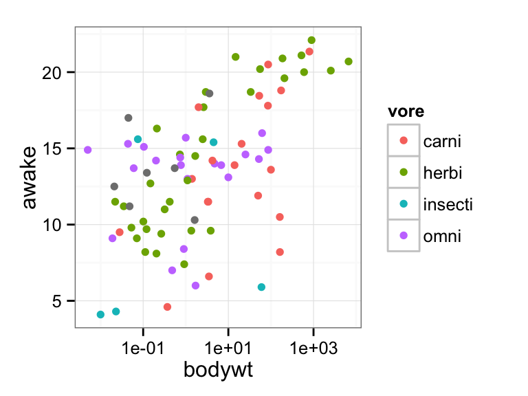

```r
ggplot(msleep, aes(x=bodywt, y=awake, color=vore)) + geom_point() + scale_x_log10()
```

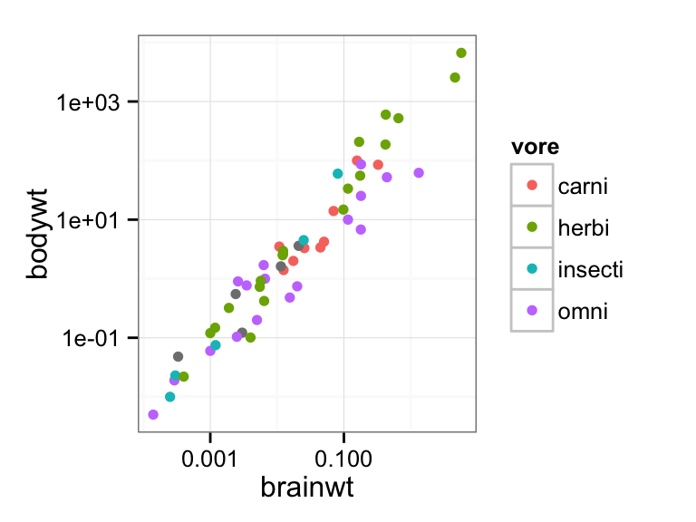

```r
ggplot(msleep, aes(x=brainwt, y=bodywt, color=vore)) + geom_point() + scale_x_log10() + scale_y_log10()
```

Log scales are more appropriate for both body weight and brain weight because there are a few species that have much larger values than most other species. If we were to use a linear scale, these outlying species would require axis ranges that are too wide to resolve any details for the majority of the species.

**Question 2: (3 pts)** *We continue working with the `msleep` dataset. Now plot the distribution of awake times for the different species, separated by “vore”. Use `geom_density()` and make sure you set the `fill` aesthetic. Make two plots: (i) one in which all distributions are plotted on top of each other, semi-transparently; (ii) one in which you facet by “vore”. Explain the benefits and draw-backs of the two graphs in 1-2 sentences.*

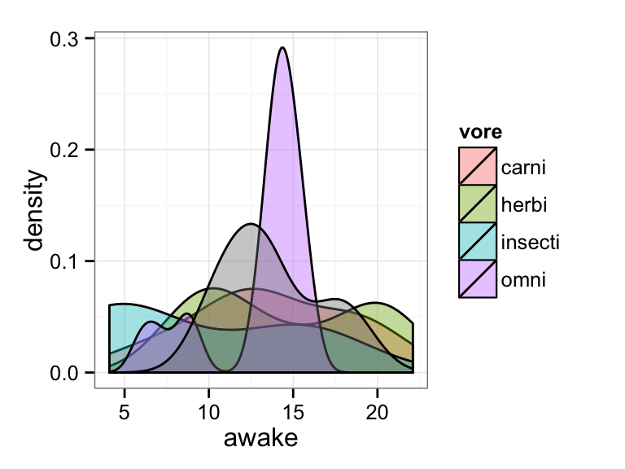

```r
ggplot(msleep, aes(x=awake, fill=vore)) + geom_density(alpha=.4)
```

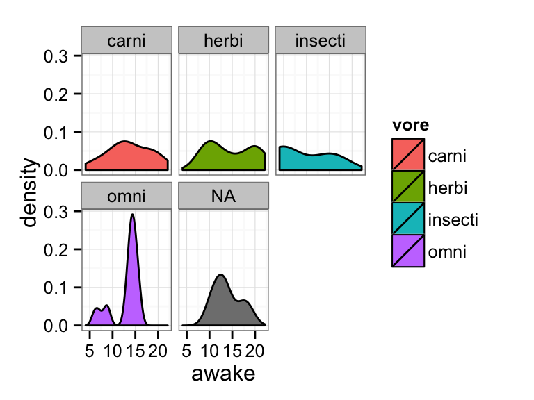

```r
ggplot(msleep, aes(x=awake, fill=vore)) + geom_density() + facet_wrap(~vore)
```

**Question 3: (4 pts)** *Explain the difference between `geom_line()` and `geom_path()`. Make up a simple data set (5-10 data points), plot it twice, once using `geom_line()` and once using `geom_path()`, and explain why each plot looks the way it does.*

`geom_line()` connects data points in the order from smallest to largest x value. `geom_path()`, by contrast, connects data points in the order in which they appear in the data frame. The following data set produces an open triangle with `geom_line()` and a closed triangle with `geom_path()`.

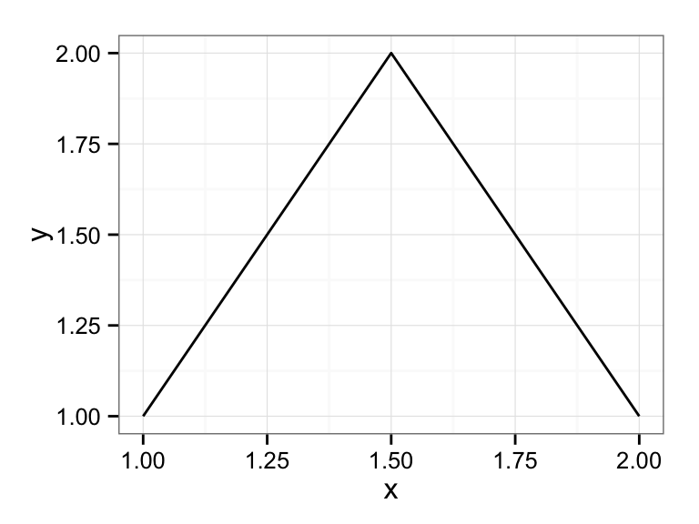

```r
d <- data.frame(x=c(1, 2, 1.5, 1), y=c(1, 1, 2, 1))
ggplot(d, aes(x=x, y=y)) + geom_line()
```

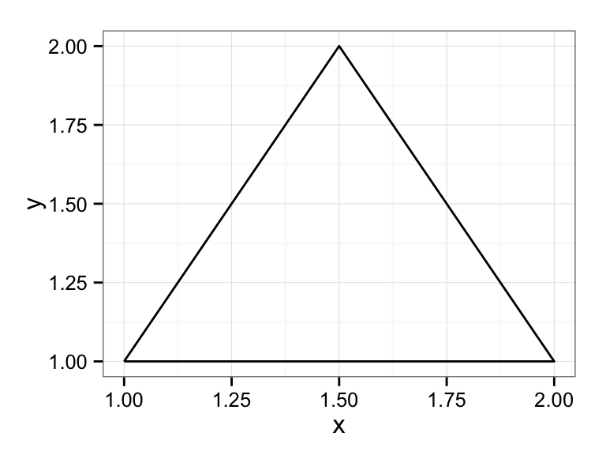

```r
ggplot(d, aes(x=x, y=y)) + geom_path()
```